# Scaling and Power Sets

Echo state networks are simple enough that there are only a few parameters, and for this notebook, we are going to set them heuristically, focusing on the effect of system size, and the number of available signals, on performance. To reduce the complexity of the problem, we are going to consider a sum of sinusoids.

```python
# Importing the sped up code from the last notebook!
from reservoir import reservoir, ESN_init
import warnings
import numpy as np

warnings.filterwarnings('ignore')

# New, simple learning task!
np.random.seed(137)
num_freqs = 5
freqs = [np.random.randint(low=0, high=100) for _ in range(num_freqs)]

print(freqs)
def fetchData(n):
    u = 0.5 * np.random.uniform(low=0., high=1.0, size=(n+1000))
    y = sum([np.sin(freq*u) for freq in freqs])
    y /= len(freqs)
    return (u, y)
```

```
[94, 38, 77, 19, 75]
```

```python
def test_NARMA10(inSize=1, outSize=1, train_cycles=10000, test_cycles=1000, alpha=0.7, resSize=5, num_batches=2, powerset=False):
    sparsity = 0.9
    Echo = ESN_init(inSize, outSize, resSize, alpha, sparsity)
    data, Y = fetchData(train_cycles+test_cycles + 50*num_batches*2)
    data_train, Y_train = data[:train_cycles+50*num_batches], Y[:train_cycles+50*num_batches]
    data_test, Y_test = data[train_cycles+50:], Y[train_cycles+50:]
    batch_size = len(data_train) // num_batches
    data_train, Y_train = data_train[:batch_size*num_batches], Y_train[:batch_size*num_batches]

    # Cut out the warmup portions.
    Y_train = Y_train.reshape((num_batches, batch_size))
    Y_train = Y_train[:, 50:].flatten()
    RA_Train, data_train = reservoir(data_train, *Echo, num_batches, powerset)
    ridge = np.zeros(tuple(RA_Train.shape))
    np.fill_diagonal(ridge, 1E-3)
    Wout, _, _, _ = np.linalg.lstsq(RA_Train.cpu().float().numpy() + torch.tensor(ridge).float().numpy(), torch.tensor(Y_train).cpu().float().numpy(), rcond=0)
    batch_size = len(data_test) // num_batches
    data_test, Y_test = data_test[:batch_size*num_batches], Y_test[:batch_size*num_batches]
    RA_Test, _ = reservoir(data_test, *Echo, num_batches, powerset)
    Yhat = RA_Test.cpu() @ Wout
    Y_test = Y_test.reshape((num_batches, batch_size))
    Y_test = Y_test[:, 50:].flatten()
    NRMSE = np.sqrt(np.divide(np.mean(np.square(Y_test-Yhat.numpy().T)),np.var(Y_test)))
    return NRMSE, Y_test, Yhat, RA_Test
```

Exhaustively using the power set is difficult, since the number of signals is exponential, but we can do it for small networks. The power set signals trivially help since they give strictly more signals, as we will see below. We implement a rudimentary hypertuner that increases the training length with system size, stopping when the performance gets worse.

```python
import torch, random
from tqdm import tqdm
from functools import reduce
import pickle as pkl
import numpy as np
import matplotlib.pyplot as plt

for powerset in [True, False]:
    np.random.seed(137)
    batches = 1000
    test_cycles=1000
    # list to store all NRMSE values
    all_nrmse = []
    # range for resSize and train_cycles
    resSizes = np.arange(1, 10, 1)
    train_steps = np.arange(1000, 10000, 1000)
    last_train_cycles = 0
    NRMSE = np.inf

    # Demonstrated loop for different sizes and cycles
    for resSize in tqdm(resSizes):
        # Hypertuning.
        for train_cycles in train_steps:
            if train_cycles < last_train_cycles:
                continue
            train_cycles = batches * train_cycles // batches
            NRMSE, _, _, _ = test_NARMA10(resSize=resSize, num_batches=batches, train_cycles=train_cycles, test_cycles=test_cycles, powerset=powerset)
            # Append the NRMSE value and configuration to the listpower
            all_nrmse.append((NRMSE, resSize, train_cycles))

            # Save results with pickle after each iteration
            with open(f'results{powerset}.pkl', 'wb') as f:
                pkl.dump(all_nrmse, f)

            # break loop if performance decreases
            if len(all_nrmse) > 1 and all_nrmse[-1][0] > all_nrmse[-2][0]:
                last_train_cycles = train_cycles
                break
```

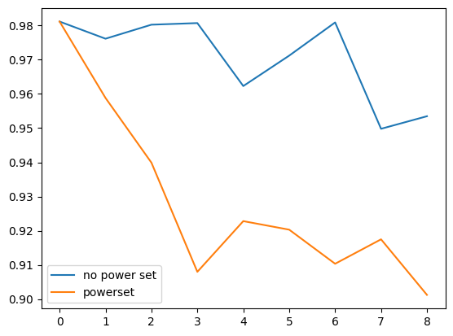

```python
def get_best_per_size(data):
    sizes = np.unique(data[:, 1])
    best_values = {}
    for size in sizes:
        size_data = data[data[:, 1] == size]
        best_value = np.min(size_data[:, 0])
        best_values[size] = best_value
    return best_values

# Find the best values per size for each dataset
with open('resultsFalse.pkl', 'rb') as f:
    all_nrmse0 = pkl.load(f)

with open('resultsTrue.pkl', 'rb') as f:
    all_nrmse1 = pkl.load(f)

a = np.array(all_nrmse0)
b = np.array(all_nrmse1)
best_a = get_best_per_size(a)
best_b = get_best_per_size(b)
plt.plot(list(best_a.values()), label='no power set')
plt.plot(list(best_b.values()), label='powerset')
plt.legend()
```

We would really like an ensemble over many reservoirs to smooth out this performance curve, and to make sure to vary the amount of training data, but this plot conveys the idea - include the additional power set signals increases performance!